# Intro to R: The Review!

18 January 2021

We learned *a lot* of skills last quarter in DAnC. You should be proud of yourselves! This is a little review of everything we learned.

# 1. Assignment operator, functions, and subsetting

We’ll start with the basics: assigning values to objects using the assignment operator `<-`.

```r
apple <- 5

orange <- 3
```

Then, we learned how to use functions in R. There are many functions out there to do the work you want!

```r
sum(apple, orange)
```

```
## [1] 8
```

However, we’re not stuck with simple numbers! We can get more complex with our objects.

```r
apple_weights <- c(0.3, 0.2, 0.25, 0.29)

orange_weights <- c(0.2, 0.18, 0.25, 0.24)

fruits <- c("apple", "orange", "banana", "pear", "persimmon", "grapefruit")
```

Then, we can subset our data using `[]`. Let’s say we want the first apple weight.

```r
apple_weights[1]
```

```
## [1] 0.3
```

Now, let’s say we want all the orange weights that are less than 0.24.

```r
orange_weights[orange_weights < 0.24]
```

```
## [1] 0.20 0.18
```

What would you write if you wanted to get the third element in `fruits`?

# 2. More complex data

We’re going to do a bit of set up by loading in our packages (aka libraries) and our data. Remember that packages are collections of functions that do specific things. Today, we’re using the `tidyverse`, which is a suite of packages all designed to make your data analysis life easier.  
For something fun this time (not that urchins aren’t fun, we just worked with them for 3 months), we’re going to be using data from Tidy Tuesday, a weekly social coding event where people work to visualize data from a dataset and share on Twitter! This data was from June 2020 on marble races; check out the [readme](https://github.com/rfordatascience/tidytuesday/blob/master/data/2020/2020-06-02/readme.md) for info on the columns and what kinds of data they hold!

```r
##################### libraries #####################

# if you don't have the tidyverse yet, uncomment the code below and run it first!
# install.packages("tidyverse")
library(tidyverse)
####################### data ########################

marbles <- readr::read_csv('https://raw.githubusercontent.com/rfordatascience/tidytuesday/master/data/2020/2020-06-02/marbles.csv')
```

# 3. Filtering observations from a data frame and the `%>%` operator

We have our `marbles` data loaded into RStudio. Let’s say we want to know the mean race time for a specific marble - maybe the one called “Snowflake.”

We can do this using functions and operators from the `tidyverse`, which is the package we loaded in.

The way we can get the mean race time for Snowflake with `tidyverse` functions is:  
1. `filter()`: filter the data frame to only include observations for Snowflake  
2. `summarize()`: calculate the mean race time

Both of these functions are from the `dplyr` package in the `tidyverse`.

We also learned how to use the pipe operator `%>%` from the `magrittr` package. This allows you to link functions together, which can be very handy! This is a pretty simple example, but we learned how powerful that operator can be (and will demonstrate later on).

```r
snowflake_mean <- marbles %>%

  filter(marble_name == "Snowflake") %>%

  summarize(mean_time = mean(time_s))


snowflake_mean
```

```
## # A tibble: 1 x 1
##   mean_time
##       <dbl>
## 1      188.
```

Try finding the mean time for another marble in the data set!

We could do this for every marble in the data frame, but that would get tedious. To streamline things, we can use the `group_by()` function also from `dplyr` to tell R: think of this as a *group*.

```r
all_means <- marbles %>%

  group_by(marble_name) %>%

  summarize(mean_time = mean(time_s))
```

# 4. Data visualization

Now that we have our data, it’s time for the fun part: visualizing it!

Let’s say we’re interested in the way that average time per lap is related to track length.

This is the most basic way to visualize it:

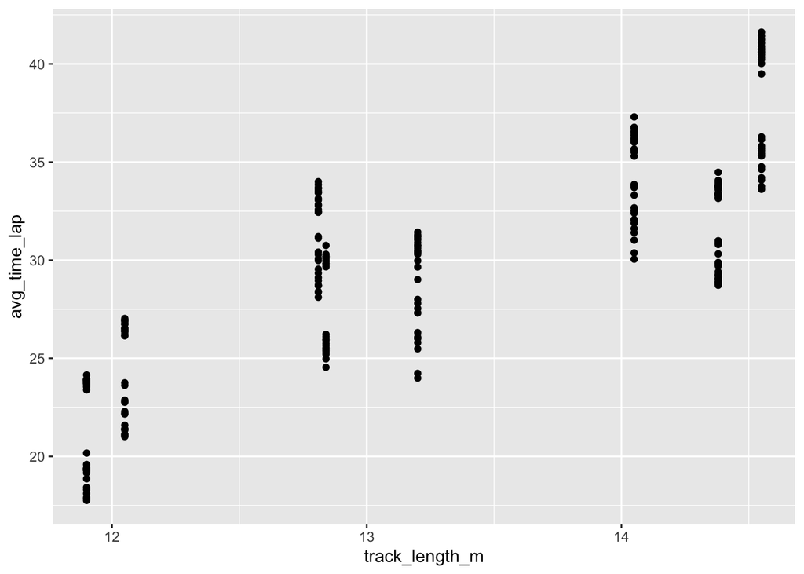

```r
ggplot(data = marbles, aes(x = track_length_m, y = avg_time_lap)) +

  geom_point()
```

But… we can make this a lot more readable!

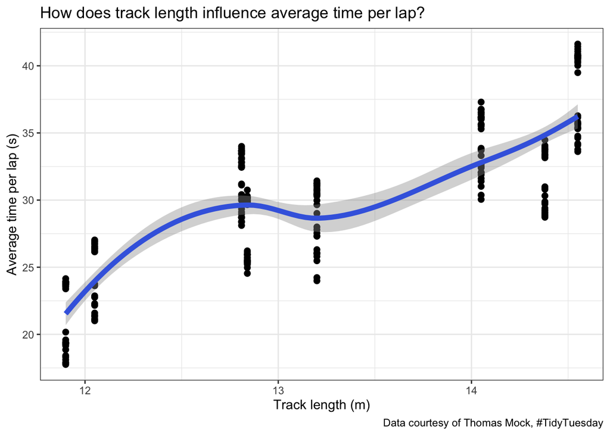

```r
ggplot(data = marbles, aes(x = track_length_m, y = avg_time_lap)) +

  geom_point(size = 2) +

  geom_smooth(color = "royalblue", size = 2) +

  theme_bw() +

  labs(x = "Track length (m)",
       y = "Average time per lap (s)",
       title = "How does track length influence average time per lap?",
       caption = "Data courtesy of Thomas Mock, #TidyTuesday",
       color = "Team name")
```

Ok, that was a pretty good plot. But let’s say we’re interested in the best marble.

We’ll filter out observations to only include races with 1 lap. Then, we’ll calculate the mean race time for each marble, and do some arrangement so that we can see the order better.

```r
best_marble <- marbles %>%

  filter(number_laps == 1) %>%

  group_by(marble_name) %>%

  summarize(mean_times = mean(time_s)) %>%

  arrange(-mean_times) %>%
  mutate(marble_name = fct_relevel(marble_name, marble_name))
```

Then, we can visualize the data! Again, you could do something basic:

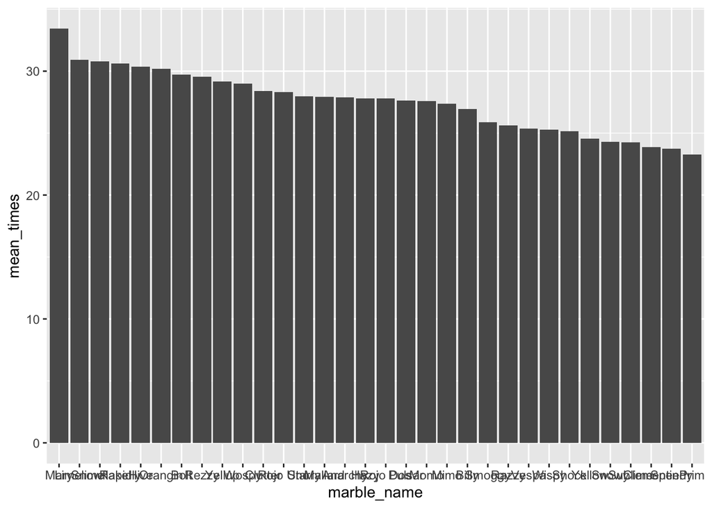

```r
ggplot(data = best_marble, aes(x = marble_name, y = mean_times)) +

  geom_col()
```

Or, you could do something fun to look at!

First, we’ll load in `viridis`, which is a package of color palettes to make choosing colors easier. There are **tons** of color palette packages out there, so lots to explore!

```r
# if you don't have viridis yet, uncomment the line below and run it first!
# install.packages("viridis")
library(viridis)
```

Then, we can plot!

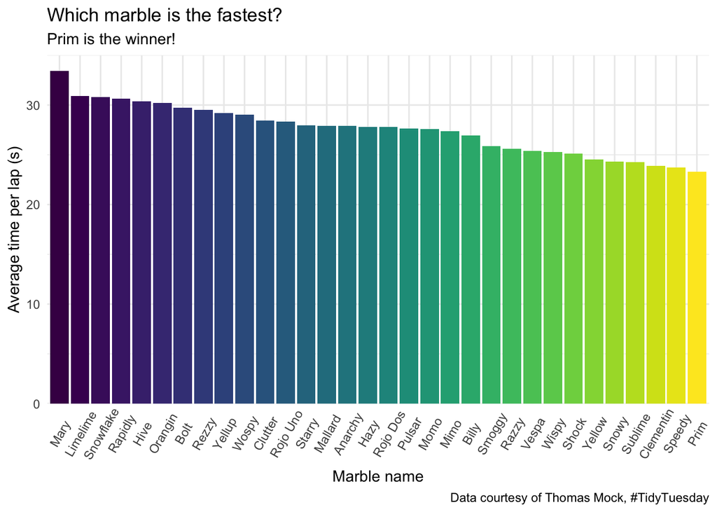

```r
ggplot(data = best_marble, aes(x = marble_name, y = mean_times)) +

  geom_col(aes(fill = marble_name)) +

  scale_y_continuous(expand = c(0, 0), limits = c(0, 35)) +

  scale_fill_viridis(option = "viridis", discrete = TRUE) +

  labs(x = "Marble name",
       y = "Average time per lap (s)",
       title = "Which marble is the fastest?",
       subtitle = "Prim is the winner!",
       caption = "Data courtesy of Thomas Mock, #TidyTuesday") +

  theme_minimal() +

  theme(legend.position = "none",
        axis.text.x = element_text(angle = 60, vjust = 0.6))
```